# Bridging the Evidence Gap in Regenerative Agriculture

We model a decision impact pathway of RA VBA (Whitney et al. 2025). Testing it with field data gathered in Kenya in 2025.

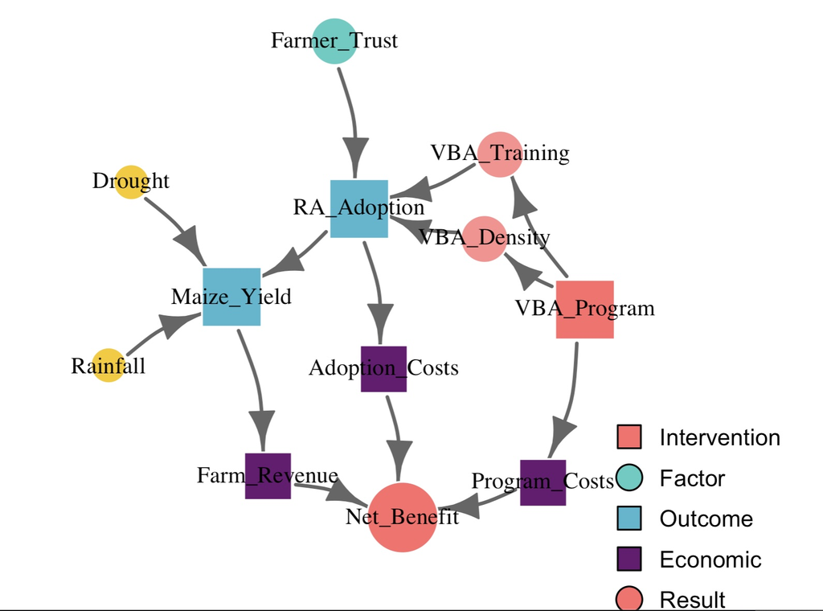

**Conceptual model of RA VBA**

## Data from the field

FGDs were conducted, one in each of in 4 counties (Kitui, Makueni, Embu, Tharaka Nithi). Each FGD was held with 20 individuals.

There were also interviews held to collect in-depth data. A total of 80 people were interviewed.

**Counts of interviews held by expert group in each county**

```r
knitr::kable(participants_data %>% group_by(County,Category) %>%
  tally())
```

| County | Category | n |
| --- | --- | --- |
| Embu | Control | 4 |
| Embu | Farm Africa | 1 |
| Embu | Farmer | 4 |
| Embu | RA farmer | 1 |
| Embu | VBA | 12 |
| Kitui | AC-CGA | 2 |
| Kitui | CoG Kitui | 1 |
| Kitui | Control | 2 |
| Kitui | Farmer | 4 |
| Kitui | VBA | 6 |
| Kitui | Village Administrator | 1 |
| Makueni | Control | 1 |
| Makueni | Farmer | 11 |
| Makueni | VBA | 5 |
| Nairobi | ICRAF | 4 |
| TNC | Control | 6 |
| TNC | Farm Africa | 1 |
| TNC | Farmer | 7 |
| TNC | VBA | 7 |

**Counts of interviews held with men and women in each county**

```r
knitr::kable(participants_data %>% group_by(County,Gender) %>%
  tally())
```

| County | Gender | n |
| --- | --- | --- |
| Embu | Female | 12 |
| Embu | Male | 10 |
| Kitui | Female | 7 |
| Kitui | Male | 9 |
| Makueni | Female | 11 |
| Makueni | Male | 6 |
| Nairobi | Female | 1 |
| Nairobi | Male | 3 |
| TNC | Female | 11 |
| TNC | Male | 10 |

### Probability of trial FGDs

This was a social and behavioral-focused discussion, trying to model the decision-making process of a farmer. It involved rating and discussing different hypothetical farmer profiles. The aim was to understand the key factors that influence a farmer’s decision to try a new RA practice for the first time.

“How often does a farmer need to be in contact with a VBA for it to make a real difference?” (VBA Contact Frequency: e.g., High, Low).

“How influential is it when a farmer sees their neighbors successfully using a practice? If many peers have adopted, does it make you more likely to try?” (Peer Adoption Rate: e.g., Low, Medium, High).

```r
knitr::kable(fgd_prob_of_trial %>% group_by(`Peer Adoption Rate`) %>% summarize(`Probability of Trial (%)` = mean(`Probability of Trial (%)`, na.rm=TRUE)))
```

| Peer Adoption Rate | Probability of Trial (%) |
| --- | --- |
| High | 50.06884 |
| Low | 34.62319 |

“Does the gender of the farmer influence their willingness to try new things? Let’s discuss.” (Farmer Gender).

```r
knitr::kable(fgd_prob_of_trial %>% group_by(`Gender of Respondent`) %>% summarize(`Probability of Trial (%)` = mean(`Probability of Trial (%)`, na.rm=TRUE)))
```

| Gender of Respondent | Probability of Trial (%) |
| --- | --- |
| F | 62.20000 |
| M | 58.50000 |
| NA | 40.72978 |

“Considering all these factors together—VBA contact, peer influence, and the farmer’s gender—what is the percentage probability (from 0% to 100%) that a farmer in this situation will try the practice?” (Probability of Trial (%)).

```r
knitr::kable(fgd_prob_of_trial %>% group_by(`VBA Contact Frequency`) %>% summarize(`Probability of Trial (%)` = mean(`Probability of Trial (%)`, na.rm=TRUE)))
```

| VBA Contact Frequency | Probability of Trial (%) |
| --- | --- |
| High | 49.86594 |
| Low | 34.82609 |

### RA adoption estimates FGDs

This was a perception and estimation exercise focused on identifying key adoption barriers (cost, difficulty, time) and quantifying the perceived value-add of the VBA program. The aim was to assess the perceived barriers and likelihood of adoption for different RA practices, with and without the support of a Village Based Advisor (VBA).

```r
knitr::kable(summary(fgd_ra_adoption_estimates[6:11]))
```

|  | Difficulty (1–5) | Cost (Low/Med/High) | Time to Benefit (months) | Adoption WITH VBA Support (%) | Adoption WITHOUT VBA (%) | …11 |
| --- | --- | --- | --- | --- | --- | --- |
|  | Min. :1.000 | Length:488 | Min. : 1.000 | Min. : 10.00 | Min. : 1.00 | Length:488 |
|  | 1st Qu.:1.000 | Class :character | 1st Qu.: 3.000 | 1st Qu.: 50.00 | 1st Qu.: 20.00 | Class :character |
|  | Median :2.000 | Mode :character | Median : 3.000 | Median : 70.00 | Median : 40.00 | Mode :character |
|  | Mean :2.436 | NA | Mean : 3.331 | Mean : 63.04 | Mean : 41.81 | NA |
|  | 3rd Qu.:4.000 | NA | 3rd Qu.: 3.000 | 3rd Qu.: 80.00 | 3rd Qu.: 60.00 | NA |
|  | Max. :5.000 | NA | Max. :18.000 | Max. :100.00 | Max. :100.00 | NA |
|  | NA’s :46 | NA | NA’s :10 | NA’s :3 | NA’s :5 | NA |

“Thinking about [RA Practice], how difficult is it to implement on a scale of 1 (easiest) to 5 (hardest)?” (Difficulty (1–5)).

“How would you rate the upfront financial cost? Low, Medium, or High?” (Cost (Low/Med/High)).

“After starting this practice, how long does it take to see a clear benefit or return?” (Time to Benefit (months)).

“Now, imagine a farmer does NOT have support from a VBA. Out of 100 farmers like you, how many would you estimate would try this practice?” (Adoption WITHOUT VBA (%)).

```r
knitr::kable(fgd_ra_adoption_estimates %>% group_by(`RA Practice`) %>% summarize(Mean = mean(`Adoption WITHOUT VBA (%)`, na.rm=TRUE)))
```

| RA Practice | Mean |
| --- | --- |
| Agroforestry | 36.58333 |
| Crop rotation | 45.83333 |
| Intercropping | 45.76271 |
| Manure application | 47.86885 |
| Microdosing | 42.26667 |
| Mulching | 39.18033 |
| Planting basins | 38.98361 |
| Ripping | 38.08197 |

“Now, imagine the same farmer has regular support, training, and follow-up from a VBA. Out of 100 farmers, how many would try it then?” (Adoption WITH VBA Support (%)).

```r
knitr::kable(fgd_ra_adoption_estimates %>% group_by(`RA Practice`) %>% summarize(MeanVBA = mean(`Adoption WITH VBA Support (%)`, na.rm=TRUE)))
```

| RA Practice | MeanVBA |
| --- | --- |
| Agroforestry | 61.95000 |
| Crop rotation | 66.16667 |
| Intercropping | 62.66667 |
| Manure application | 65.13115 |
| Microdosing | 59.80328 |
| Mulching | 64.59016 |
| Planting basins | 62.14754 |
| Ripping | 61.91803 |

### Practice scenarios FGDs

Practice scenarios were based on a structured elicitation where the same five scenarios were presented to all participants, and each provided their own yield estimates based on their experience and knowledge.

```r
knitr::kable(summary(fgd_practice_scenarios[c(7,8,15,16)]))
```

|  | Baseline (bags/ac) | Land (ac) | Lowest Yield in bags/ac | Highest Yield in bags/ac |
| --- | --- | --- | --- | --- |
|  | Min. : 6 | Min. :1.0 | Min. : 0.000 | Min. : 0.00 |
|  | 1st Qu.: 8 | 1st Qu.:1.0 | 1st Qu.: 2.000 | 1st Qu.: 4.00 |
|  | Median : 8 | Median :2.0 | Median : 3.000 | Median : 7.00 |
|  | Mean : 8 | Mean :1.6 | Mean : 6.333 | Mean : 11.97 |
|  | 3rd Qu.: 8 | 3rd Qu.:2.0 | 3rd Qu.: 7.000 | 3rd Qu.: 15.00 |
|  | Max. :10 | Max. :2.0 | Max. :60.000 | Max. :150.00 |
|  | NA | NA | NA’s :7 | NA’s :4 |

*Scenario Descriptions & Results*

Scenario Definitions and Average Yield Estimates

| Scenario Name | Weather | Soil | Management | Practice 1 | Practice 2 | Practice 3 | Count | Avg_Baseline | Avg_Lowest_Yield | Avg_Highest_Yield |
| --- | --- | --- | --- | --- | --- | --- | --- | --- | --- | --- |
| SCENARIO A | Average (≈500–600 mm) | Medium | Strong | Ripping | Manure application (5 t/ac) | Microdosing fertilizer | 87 | 8 | 8.620690 | 17.339081 |
| SCENARIO B | Drought (≈300 mm) | Poor | Average | Mulching | NA | NA | 84 | 8 | 4.464286 | 9.505952 |
| SCENARIO C | Good (≈700 mm) | Good | Average | Intercropping | Mulching | Manure application (5 t/ac) | 85 | 6 | 7.676471 | 13.958823 |
| SCENARIO C | Good (≈700 mm) | \ | Average | Intercropping | Mulching | Manure application (5 t/ac) | 1 | 6 | 5.000000 | 10.000000 |
| SCENARIO D | Average (≈500–600 mm) | Poor | Weak | Planting basins | NA | NA | 84 | 10 | 5.619048 | 8.264881 |
| SCENARIO E | Average (≈500–600 mm) | Medium | Strong | Agroforestry (trees on farm) | Crop rotation | NA | 87 | 8 | 5.241379 | 10.988506 |

SCENARIO A: Average rainfall (500-600mm), Medium soil, Strong management. RA practices include Ripping + Manure application (5 t/ac) + Microdosing fertilizer. The results were Baseline ~8 bags/ac, with yields ranging from 8.6 to 17.3 bags/ac on average

SCENARIO B: Drought (300mm), Poor soil, Average management. RA Practices include Mulching only. The results were Baseline ~8 bags/ac, with yields ranging from 4.5 to 9.5 bags/ac on average

SCENARIO C: Good rainfall (700mm), Good soil, Average management. the RA Practices were Intercropping + Mulching + Manure application (5 t/ac). The results were Baseline ~6 bags/ac, with yields ranging from 7.7 to 14 bags/ac on average

The data shows that participants perceived SCENARIO A (intensive package under average conditions) and SCENARIO C (diversification under good conditions) as having the highest potential yields, while SCENARIO B (drought conditions) and SCENARIO D (poor soil with basic practices) were seen as most challenging.

The wide ranges in responses (visible in the original data) reflect the diversity of participant experiences and highlight the context-dependent nature of RA practice outcomes.

### Economic returns FDGs

FGD questions on the economic returns a detailed, participatory costing exercise where farmers built a cost model for each practice from the ground up. The aim was to understand the detailed costs (both labor and inputs) associated with specific Regenerative Agriculture (RA) practices.

```r
knitr::kable(summary(fgd_economic_return_data[c(10,15,19)]))
```

|  | Total Labour Cost (KSh) | Total Inputs Cost (KSh) | Unit Value (KSh) |
| --- | --- | --- | --- |
|  | Min. : 0 | Min. : 0 | Min. : 0 |
|  | 1st Qu.: 1000 | 1st Qu.: 0 | 1st Qu.: 0 |
|  | Median : 2200 | Median : 0 | Median : 0 |
|  | Mean : 4878 | Mean : 4475 | Mean : 1563 |
|  | 3rd Qu.: 4500 | 3rd Qu.: 2500 | 3rd Qu.: 900 |
|  | Max. :90000 | Max. :150000 | Max. :90005 |
|  | NA | NA’s :1 | NA’s :103 |

RA Practice / Activity “Let’s list the most common RA practices you know or use.”

```r
knitr::kable(table(fgd_economic_return_data$`RA Practice / Activity`))
```

| Var1 | Freq |
| --- | --- |
| Agroforestry | 37 |
| Crop rotation | 39 |
| Intercropping | 40 |
| Manure application | 49 |
| Microdosing | 50 |
| Mulching | 42 |
| Planting basins | 43 |
| Ripping | 48 |

“For [e.g., Composting], what are the specific steps or tasks involved?” (This helps break down the activity for costing).

“For each task, what unit do you measure it in? (e.g., days, acres, piles)” (Type of Unit).

“How many of these units are typically required per acre per season?” (Num.of .Units).

“How many person-days of labor does this task take per unit?” (Num.of .Days).

“If you were to hire labor for this, what would be the daily rate?” (Used to calculate Total Labour Cost (KSh)).

“What specific inputs are required for this practice? (e.g., manure, seeds, mulch)” (Input Type).

“What unit is that input measured in? (e.g., tons, bags, kg)” (Type of Unit-inputs).

“How many units are needed per acre?” (No.of. Units-inputs).

“What is the current market cost per unit of this input?” (Cost/Unit-inputs).

“So, what is the total cost for this input for this practice?” (Total Cost for Input (KSh)).

## Field Data Validation

```r
fgd_ra_adoption_estimates$`Adoption WITHOUT VBA (%)` <- as.numeric(fgd_ra_adoption_estimates$`Adoption WITHOUT VBA (%)`)
field_stats <- fgd_ra_adoption_estimates %>%
  summarize(
    avg_adoption_vba = mean(`Adoption WITH VBA Support (%)`, na.rm = TRUE),
    avg_adoption_no_vba = mean(`Adoption WITHOUT VBA (%)`, na.rm = TRUE),
    vba_impact = avg_adoption_vba - avg_adoption_no_vba,
    avg_difficulty = mean(`Difficulty (1–5)`, na.rm = TRUE),
    avg_benefit_months = mean(`Time to Benefit (months)`, na.rm = TRUE)
  )
```

VBA impact was 21.2 % points, the average difficulty 2.4 /5. The average time to Benefit was 3.3 months.

# Simulating the Impact of Village-Based Advisors on Regenerative Agriculture

We applied the field data to a probabilistic Monte Carlo simulation model to estimate the causal effect and economic value of a Village-Based Advisor (VBA) program on the adoption of Regenerative Agriculture (RA) practices among smallholder farmers in Kenya over a 25-year horizon. We combined a theory-based causal structure with a probabilistic framework to quantify not only the expected value of the VBA program but also the confidence in and risks associated with that outcome. The full model in R can be found here https://github.com/CWWhitney/RA_and_VBA/blob/main/vba_model_kenya.R

Our model structure is based on a pre-defined Directed Acyclic Graph (DAG) (shown above) that outlines the impact pathway. The core logic follows this causal chain: *Intervention:* The VBA program increases the density and training quality of advisors. *Adoption:* These advisors, moderated by initial farmer trust, increase the adoption rate of RA practices. *Biophysical Outcome:* Higher adoption leads to improved maize yields, which are also influenced by stochastic environmental factors like rainfall variability and drought. *Economic Outcome:* The change in yield, combined with maize prices and the costs of both the program and practice adoption, determines the final net economic benefit.

To account for uncertainty, we defined all key input parameters as probability distributions (e.g., `normal`, `uniform`, `posnorm`). These distributions were specified in an input CSV file, capturing the range of plausible values for each variable based on literature, expert opinion, and field data. Our model performs a Monte Carlo simulation, running thousands of iterations. In each iteration, a value for every input is randomly sampled from its respective distribution, ensuring that the full range of uncertainty is propagated through the model. All variable estimates can be found here https://github.com/CWWhitney/RA_and_VBA/blame/main/data/inputs_vba_kenya.csv

The model calculates outcomes for two scenarios simultaneously: *Control Scenario:* Simulates a future where RA adoption continues from a field-calibrated baseline at a slow, organic growth trend, without any VBA program. *Treatment Scenario:* Simulates a future with the VBA program, where adoption is boosted by a factor derived from field data (`vba_boost`), which is itself a function of VBA density, effectiveness, training quality, and farmer trust.

We made key variables like adoption rates and yields time-variant using the `decisionSupport` `vv()` function, which introduces random annual fluctuations around a defined trend (e.g., a 0.5% annual increase in baseline adoption).

We modeled the impact of drought as a stochastic event using the chance_event() function, assigning an annual probability of occurrence and a corresponding negative yield impact.

For both scenarios, annual cash flows were calculated as: `Annual Net Benefit = (Yield × Maize Price) - (RA Adoption Costs) - (VBA Program Costs)` The VBA program costs were only applied in the treatment scenario. The comparative annual net benefit was derived by subtracting the control net benefit from the treatment net benefit. These annual streams of comparative net benefits were then discounted to their Net Present Value (NPV) using a social discount rate. The Return on Investment (ROI) was calculated as the NPV of the comparative benefits divided by the NPV of the VBA program costs.

```r
# Source our model
source("vba_model_kenya.R")

# ---- 3. RUN THE MONTE CARLO SIMULATION ----
set.seed(42)  # For reproducible results

# Run the simulation 10,000 times

simulation_results <- mcSimulation(
  estimate = estimate_read_csv("data/inputs_vba_kenya.csv"),
  model_function = vba_causal_effect,
  numberOfModelRuns = 1e4, #run 10,000 times
  functionSyntax = "plainNames"
)
```

```r
knitr::kable(summary(simulation_results$y[c(2,4,10)]))
```

|  | ROI | Final_Adoption_VBA | Mean_VBA_Cost |
| --- | --- | --- | --- |
|  | Min. : -3071.9 | Min. :51.90 | Min. : 0.004674 |
|  | 1st Qu.: 106.9 | 1st Qu.:61.16 | 1st Qu.: 6.864096 |
|  | Median : 204.9 | Median :63.24 | Median :11.157345 |
|  | Mean : 580.9 | Mean :63.24 | Mean :11.950602 |
|  | 3rd Qu.: 378.7 | 3rd Qu.:65.29 | 3rd Qu.:15.970703 |
|  | Max. :703752.5 | Max. :75.25 | Max. :56.119110 |

The Net Present Value (i.e. current value of the future benefits) of the VBA options. Here we plot the distribution for the VBA and frame the projected NPV.

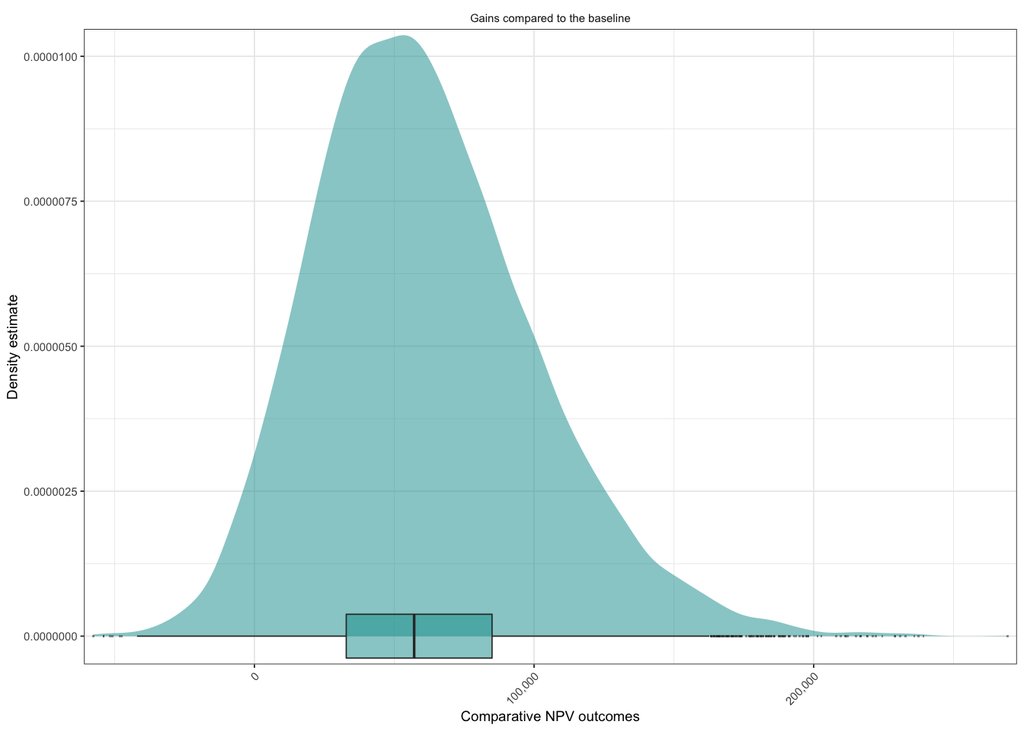

```r
source("functions/plot_distributions.R")
plot_distributions(mcSimulation_object = simulation_results,
                                    vars = "NPV_Comparative",
                   old_names = "NPV_Comparative",
                   new_names = "Gains compared to the baseline",
                                    method = 'boxplot_density',
                                    base_size = 7,
                                    x_axis_name = "Comparative NPV outcomes")
```

The adoption and yield impacts of the Intervention show a final RA Adoption - in the baseline 42.1%. The final RA Adoption with VBA was 63.2%. The Average Yield Increase 0.23 tons/ha/year.